# Exposome Data Integration with Omic Data

Carles Hernandez-Ferer and Juan R. Gonzalez

24 marzo 2017

#### Abstract

This is an introductory guide to integration analysis between exposome and omics data with R package rexposome. The document ilustrates two types of analysis: 1) Association analysis, that are performed between exposome and a single omic data-set; and 2) Integration analysis where multiple data-sets, including exposome data, are analysed at the same time.

#### Package version: rexposome 0.99.57

# 1 Introduction

## 1.1 Pipeline

## 1.2 Data Format

## 1.3 Installation

```r
devtools::install_github("isglobal-brge/omicRexposome")
```

The methods provided by `rexposome` and used in this document relies in other existing Bioconductor packages. All association and integration methods requires a *MultiDataSet* object. The following are the R packages used in association analyses:

- *snpStats*
- *limma*

These are the packages used in the integration analyses:

- *omicade4*
- *[pma](http://cran.fhcrc.org/web/packages/pma/index.html)*

# 2 Analysis

The data used for in this vignete has two differens sources:

- `rexposome` - exposome data will be used
- `BRGEdata` - gene expresion and methylation data will be used

Under this sections two types of analysis are explained: **Association Analysis** and **Integration Analysis**.

Both types of analysis requests a `MultiDataSet` object. While **Association Analysis** are performed using a `MultiDataSet` object that contains an `ExposomeSet` plus a `SnpSet`, `MethylationSet` or `ExpressionSet`, **Integration Analysis** needs a `MultiDataSet` object with, at last, two of these objects.

We start loading `omicRexposome`:

```r
library(omicRexposome)
```

The *exposome* data is loaded from `rexposome` package as it is illustrated in its vignettes:

```r
library(rexposome)

path <- paste0(path.package("rexposome"), .Platform$file.sep, "extdata")
description <- paste0(path, .Platform$file.sep, "description.csv")
phenotype <- paste0(path, .Platform$file.sep, "phenotypes.csv")
exposures <- paste0(path, .Platform$file.sep, "exposures.csv")

exp <- read_exposome(
    exposures = exposures,
    description = description,
    phenotype = phenotype,
    exposures.samCol = 1,
    description.expCol = 2,
    description.famCol = 1,
    phenotype.samCol = 1
)
```

## 2.1 Associaction Analysis

Then we load the `MultiDataSet` package to be able to create the input objects for association methods.

```r
library(MultiDataSet)
```

### 2.1.1 Exposome - Methylome Data Associaction

The goal of this analysis is to perform an EWAS between the methylation levels and the exposures. To this end, a `MultiDataSet` with an `ExposomeSet` and a `MethylationSet` is required.

```r
data("mset_rd", package = "BRGEdata")
```

Once the data is loaded a `MultiDataSet` object is created containing both data-sets:

```r
mds <- createMultiDataSet()
mds <- add_methy(mds, mset_r)
mds <- add_exp(mds, exp)
```

After creating the `MultiDataSet` created the common samples between sets are kept and the others discarded:

```r
mds <- commonSamples(mds)
```

```r
mds
```

```
## Object of class 'MultiDataSet'
##  . assayData: 2 elements
##     . methylation: 10000 features, 30 samples
##     . exposures: 88 features, 30 samples
##  . featureData:
##     . methylation: 10000 rows, 17 cols (chromosome, ..., Regulatory_Feature_Group)
##     . exposures: 88 rows, 7 cols (Family, ..., _imp)
##  . rowRanges:
##     . methylation: YES
##     . exposures: NO
##  . phenoData:
##     . methylation: 30 samples, 1 cols (id)
##     . exposures: 30 samples, 10 cols (whistling_chest, ..., blood_pre)
```

After obtaining the common samples, the association analysis between CpGs and exposures is done using `assocME`. This method requires a `MultiDataSet` object and a formula with the covariates. The optional argument `select` allows to perform the association on a sub-set of exposures (if `set = "exposures`) or sub-set of *outcomes*(if `set = "phenotypes"`).

```r
ewas <- assocME(mds, ~sex+age,
    select=c("Pb", "Co", "THM", "G_pesticides"))
```

The result is an object of class `ResultSet`:

```r
ewas
```

```
## Object of class 'ResultSet'
##  . created with: assocME
##  . original input: ExposomeSet, MethylationSet
##     . names: exposures, methylation
##  . #results: 4 ( error: 0 )
##  . featureData:  2
##     . exposures: 88x7
##     . methylation: 10000x17
```

The raw results of the analysis can be obtained using the method `extract` and giving it the exposures of interest. If no exposure (or phenotype) is given, `extract` will return a table with the results for all the exposures (or phenotypes).

```r
rid(ewas)
```

```
## [1] "Pb"           "Co"           "THM"          "G_pesticides"
```

```r
head(topTable(ewas, rid="G_pesticides")[ , 1:8], n=3)
```

```
##                 logFC    AveExpr        t     P.Value adj.P.Val         B
## cg14968300 0.04746598 0.23016402 3.996482 0.000441143 0.9464373 -1.014962
## cg22186831 0.02131716 0.03635217 3.507234 0.001589535 0.9464373 -2.262934
## cg03807842 0.03074107 0.81880234 3.415620 0.002011631 0.9464373 -2.490275
##            chromosome  position
## cg14968300       chr8  23585186
## cg22186831       chr5 176544048
## cg03807842       chr7    967038
```

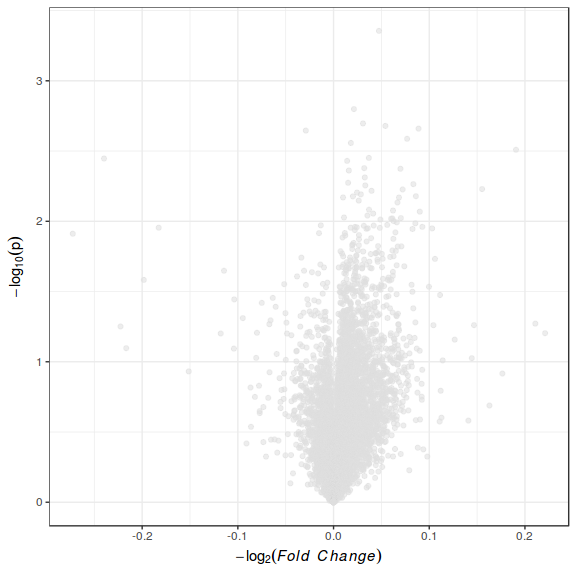

```r
plotAssociation(ewas, rid="G_pesticides", type="volcano")
```

The same analysis can be done using an `ExposomeClust` instead of an `ExposomeSet`.

```r
data("eclust", package = "rexposome")
```

```r
sampleNames(expo_c) <- gsub("SIMSAB", "id", sampleNames(expo_c))
```

```r
mds <- createMultiDataSet()
mds <- add_methy(mds, mset_r)
mds <- add_cls(mds, expo_c)
```

After creating the `MultiDataSet` the method `assocME` can be called directly. It will look for the common samples before running the association test.

```r
methy <- assocME(mds, ~sex+age)
methy
```

```
## Object of class 'ResultSet'
##  . created with: assocME
##  . original input: ExposomeClust, MethylationSet
##     . names: cluster, methylation
##  . #results: 1 ( error: 0 )
##  . featureData:  2
##     . cluster: 99x7
##     . methylation: 10000x17
```

The results of the association analysis can be obtained using the tag `"cluster"` in the argument `rid` of `extract` method:

```r
head(topTable(methy, rid="cluster")[ , 1:8], n=3)
```

```
##                   logFC   AveExpr         t      P.Value adj.P.Val
## cg04129885 -0.083863374 0.8840104 -4.539663 2.747571e-05 0.2747571
## cg10502303 -0.024964721 0.3153444 -3.611163 6.217088e-04 0.9655895
## cg15383705 -0.008873278 0.9098623 -3.511795 8.495531e-04 0.9655895
##                    B chromosome  position
## cg04129885  0.514408       chr4   2439700
## cg10502303 -2.494103       chr2  16847831
## cg15383705 -2.791193      chr10 114699120
```

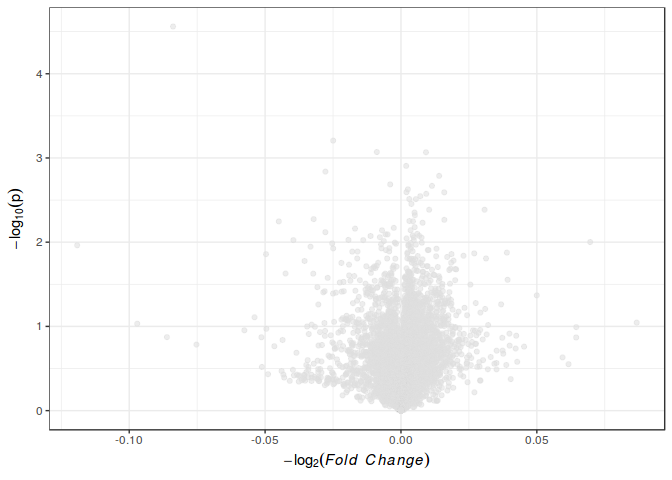

```r
plotAssociation(methy, rid="cluster", type="volcano")
```

### 2.1.2 Exposome - Transcriptome Data Associaction

The aim of this analysis is to perform an association test between the gene expression levels and the exposures. To this end, a `MultiDataSet` with an `ExposomeSet` and an `ExpressionSet` is required.

```r
data("gexp_rd", package="BRGEdata")
```

Once the data is loaded a `MultiDataSet` object is created containing both data-sets:

```r
mds <- createMultiDataSet()
mds <- add_genexp(mds, gexp_r)
mds <- add_exp(mds, exp)
```

After creating the `MultiDataSet` created the common samples between sets are kept and the others discarded:

```r
mds <- commonSamples(mds)
```

```r
mds
```

```
## Object of class 'MultiDataSet'
##  . assayData: 2 elements
##     . expression: 67528 features, 17 samples
##     . exposures: 88 features, 17 samples
##  . featureData:
##     . expression: 67528 rows, 11 cols (transcript_cluster_id, ..., gene_assignment)
##     . exposures: 88 rows, 7 cols (Family, ..., _imp)
##  . rowRanges:
##     . expression: YES
##     . exposures: NO
##  . phenoData:
##     . expression: 17 samples, 1 cols (id)
##     . exposures: 17 samples, 10 cols (whistling_chest, ..., blood_pre)
```

The association analysis between exposures and gene expression is done using the method `assocGE`. This method has the same behavior than `assocME`.

```r
gexp <- assocGE(mds, ~sex+age,
    select=c("Pb", "Co", "THM", "G_pesticides"))
```

The obtained object is also a `ResultSet`. The raw table can be obtained using `extract`:

```r
tt <- topTable(gexp)
table(tt$exposure)
```

```
##
##           Co G_pesticides           Pb          THM
##        67528        67528        67528        67528
```

```r
head(tt[ , c("logFC", "P.Value", "adj.P.Val", "exposure")], n=5)
```

```
##                    logFC      P.Value adj.P.Val exposure
## TC15000519.hg.1 3.377181 7.050365e-06 0.1370103       Pb
## TC0X000004.hg.1 5.554031 1.014470e-05 0.1370103       Pb
## TC0Y000004.hg.1 5.554031 1.014470e-05 0.1370103       Pb
## TC15001006.hg.1 5.554031 1.014470e-05 0.1370103       Pb
## TC15001024.hg.1 5.554031 1.014470e-05 0.1370103       Pb
```

And all three QQ, Manhattan and volcano plots can be dawn using `plotAssociation`:

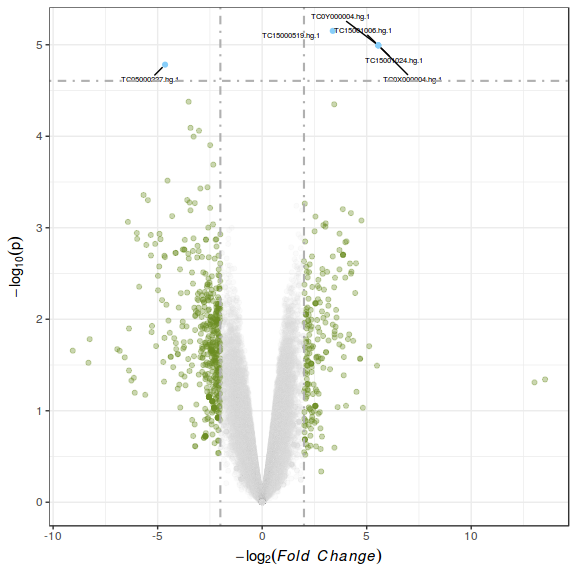

```r
plotAssociation(gexp, rid="Pb", type="volcano",
    tPV=-log(10e-3), tFC=2)
```

The same analysis can be done using an `ExposomeClust` instead of an `ExposomeSet`.

```r
mds <- createMultiDataSet()
mds <- add_genexp(mds, gexp_r)
mds <- add_cls(mds, expo_c)
```

After creating the `MultiDataSet` the method `assocGE` can be called directly. It will look for the common samples before running the association test.

```r
gexp <- assocGE(mds, ~sex+age)
gexp
```

```
## Object of class 'ResultSet'
##  . created with: assocGE
##  . original input: ExposomeClust, ExpressionSet
##     . names: cluster, expression
##  . #results: 1 ( error: 0 )
##  . featureData:  2
##     . cluster: 99x7
##     . expression: 67528x11
```

The results of the association analysis can be obtained using the tag `"cluster"` in the argument `rid` of `extract` method:

```r
head(topTable(gexp, rid="cluster"), n=3)
```

```
##                 transcript_cluster_id     probeset_id chromosome strand
## TC11001978.hg.1       TC11001978.hg.1 TC11001978.hg.1      chr11      -
## TC05001546.hg.1       TC05001546.hg.1 TC05001546.hg.1       chr5      -
## TC14002267.hg.1       TC14002267.hg.1 TC14002267.hg.1      chr14      -
##                     start       end total_probes category locus.type
## TC11001978.hg.1  66963391  66964638           30     main     Coding
## TC05001546.hg.1  81368874  81369521           30     main     Coding
## TC14002267.hg.1 106877619 106878126           34     main     Coding
##                 gene_assignment notes      logFC  AveExpr         t
## TC11001978.hg.1             ---   --- -0.2955435 2.761535 -3.897528
## TC05001546.hg.1 ENST00000504846   --- -0.2525415 2.033070 -3.845232
## TC14002267.hg.1 ENST00000390619   ---  0.3858421 3.738451  3.827884
##                      P.Value adj.P.Val         B transcript_cluster_id
## TC11001978.hg.1 0.0008907215 0.9999848 -1.740017       TC11001978.hg.1
## TC05001546.hg.1 0.0010065659 0.9999848 -1.800505       TC05001546.hg.1
## TC14002267.hg.1 0.0010482117 0.9999848 -1.820622       TC14002267.hg.1
##                     probeset_id chromosome strand     start       end
## TC11001978.hg.1 TC11001978.hg.1      chr11      -  66963391  66964638
## TC05001546.hg.1 TC05001546.hg.1       chr5      -  81368874  81369521
## TC14002267.hg.1 TC14002267.hg.1      chr14      - 106877619 106878126
##                 total_probes category locus.type gene_assignment notes
## TC11001978.hg.1           30     main     Coding             ---   ---
## TC05001546.hg.1           30     main     Coding ENST00000504846   ---
## TC14002267.hg.1           34     main     Coding ENST00000390619   ---
```

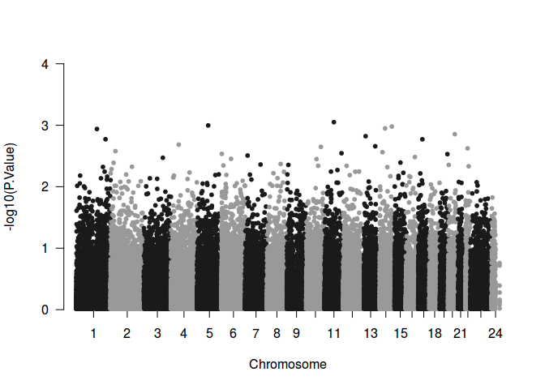

```r
plotAssociation(gexp, rid="cluster", type="manhattan")
```